# Cyclistic Case Study: Analyze Phase

Shresth

2025-05-01

# Introduction

This case study explores how annual members and casual riders use the Cyclistic bike-share system differently. The analysis is based on cleaned Q1 datasets from 2019 and 2020, prepared as part of the Google Data Analytics Capstone Project.

The business objective is to identify usage trends and behavioral differences that can inform a marketing strategy to convert more casual riders into annual members.

The following R analysis includes: - Descriptive statistics of ride patterns - Aggregated comparisons between user types - Visualizations of usage trends by day of the week and demographic segments

The ultimate goal is to derive actionable insights from user behavior that can support strategic decision-making.

# Installing Packages

```r
library(readxl)
library(dplyr)
```

```r
library(ggplot2)
library(lubridate)
library(janitor)
library(here)
library(scales)
```

# Collect Data

We cleaned two files ‘Divvy_trips_2019_Q1.xlsx’ and ‘Divvy_trips_2020_Q1.xlsx’ and their cleaned data is saved in Cleaned_data directory, which is why we installed ‘here’ library to work with structured paths

```r
df_2019 <- read_excel(here("Cleaned_data","Divvy_Trips_2019_Q1_cleaned.xlsx"))
df_2020 <- read_excel(here("Cleaned_data","Divvy_Trips_2020_Q1_cleaned.xlsx"))
```

Preview of both dataset

```r
head(df_2019)
```

```
## # A tibble: 6 × 15
##    trip_id start_time          end_time            bikeid tripduration
##      <dbl> <dttm>              <dttm>               <dbl>        <dbl>
## 1 21742443 2019-01-01 00:04:37 2019-01-01 00:11:07   2167          390
## 2 21742444 2019-01-01 00:08:13 2019-01-01 00:15:34   4386          441
## 3 21742445 2019-01-01 00:13:23 2019-01-01 00:27:12   1524          829
## 4 21742446 2019-01-01 00:13:45 2019-01-01 00:43:28    252         1783
## 5 21742447 2019-01-01 00:14:52 2019-01-01 00:20:56   1170          364
## 6 21742448 2019-01-01 00:15:33 2019-01-01 00:19:09   2437          216
## # ℹ 10 more variables: from_station_id <dbl>, from_station_name <chr>,
## #   to_station_id <dbl>, to_station_name <chr>, usertype <chr>, gender <chr>,
## #   birthyear <dbl>, ride_length <dttm>, day_of_week <chr>, age_group <chr>
```

```r
head(df_2020)
```

```
## # A tibble: 6 × 15
##   ride_id          rideable_type started_at          ended_at
##   <chr>            <chr>         <dttm>              <dttm>
## 1 EACB19130B0CDA4A docked_bike   2020-01-21 20:06:59 2020-01-21 20:14:30
## 2 8FED874C809DC021 docked_bike   2020-01-30 14:22:39 2020-01-30 14:26:22
## 3 789F3C21E472CA96 docked_bike   2020-01-09 19:29:26 2020-01-09 19:32:17
## 4 C9A388DAC6ABF313 docked_bike   2020-01-06 16:17:07 2020-01-06 16:25:56
## 5 943BC3CBECCFD662 docked_bike   2020-01-30 08:37:16 2020-01-30 08:42:48
## 6 6D9C8A6938165C11 docked_bike   2020-01-10 12:33:05 2020-01-10 12:37:54
## # ℹ 11 more variables: start_station_name <chr>, start_station_id <dbl>,
## #   end_station_name <chr>, end_station_id <dbl>, start_lat <dbl>,
## #   start_lng <dbl>, end_lat <dbl>, end_lng <dbl>, member_casual <chr>,
## #   ride_length <dttm>, day_of_week <chr>
```

# Checking Column names for merging

```r
colnames(df_2019)
```

```
##  [1] "trip_id"           "start_time"        "end_time"
##  [4] "bikeid"            "tripduration"      "from_station_id"
##  [7] "from_station_name" "to_station_id"     "to_station_name"
## [10] "usertype"          "gender"            "birthyear"
## [13] "ride_length"       "day_of_week"       "age_group"
```

```r
colnames(df_2020)
```

```
##  [1] "ride_id"            "rideable_type"      "started_at"
##  [4] "ended_at"           "start_station_name" "start_station_id"
##  [7] "end_station_name"   "end_station_id"     "start_lat"
## [10] "start_lng"          "end_lat"            "end_lng"
## [13] "member_casual"      "ride_length"        "day_of_week"
```

# Combining into a single file

```r
(df_2019<-rename(df_2019, ride_id = trip_id,
                rideable_type=bikeid,
                started_at = start_time,
                ended_at = end_time,
                start_station_name = from_station_name,
                start_station_id = from_station_id,
                end_station_name = to_station_name,
                end_station_id = to_station_id,
                member_casual = usertype))
```

```
## # A tibble: 365,053 × 15
##     ride_id started_at          ended_at            rideable_type tripduration
##       <dbl> <dttm>              <dttm>                      <dbl>        <dbl>
##  1 21742443 2019-01-01 00:04:37 2019-01-01 00:11:07          2167          390
##  2 21742444 2019-01-01 00:08:13 2019-01-01 00:15:34          4386          441
##  3 21742445 2019-01-01 00:13:23 2019-01-01 00:27:12          1524          829
##  4 21742446 2019-01-01 00:13:45 2019-01-01 00:43:28           252         1783
##  5 21742447 2019-01-01 00:14:52 2019-01-01 00:20:56          1170          364
##  6 21742448 2019-01-01 00:15:33 2019-01-01 00:19:09          2437          216
##  7 21742449 2019-01-01 00:16:06 2019-01-01 00:19:03          2708          177
##  8 21742450 2019-01-01 00:18:41 2019-01-01 00:20:21          2796          100
##  9 21742451 2019-01-01 00:18:43 2019-01-01 00:47:30          6205         1727
## 10 21742452 2019-01-01 00:19:18 2019-01-01 00:24:54          3939          336
## # ℹ 365,043 more rows
## # ℹ 10 more variables: start_station_id <dbl>, start_station_name <chr>,
## #   end_station_id <dbl>, end_station_name <chr>, member_casual <chr>,
## #   gender <chr>, birthyear <dbl>, ride_length <dttm>, day_of_week <chr>,
## #   age_group <chr>
```

## Inspecting the dataset

```r
head(df_2019)
```

```
## # A tibble: 6 × 15
##    ride_id started_at          ended_at            rideable_type tripduration
##      <dbl> <dttm>              <dttm>                      <dbl>        <dbl>
## 1 21742443 2019-01-01 00:04:37 2019-01-01 00:11:07          2167          390
## 2 21742444 2019-01-01 00:08:13 2019-01-01 00:15:34          4386          441
## 3 21742445 2019-01-01 00:13:23 2019-01-01 00:27:12          1524          829
## 4 21742446 2019-01-01 00:13:45 2019-01-01 00:43:28           252         1783
## 5 21742447 2019-01-01 00:14:52 2019-01-01 00:20:56          1170          364
## 6 21742448 2019-01-01 00:15:33 2019-01-01 00:19:09          2437          216
## # ℹ 10 more variables: start_station_id <dbl>, start_station_name <chr>,
## #   end_station_id <dbl>, end_station_name <chr>, member_casual <chr>,
## #   gender <chr>, birthyear <dbl>, ride_length <dttm>, day_of_week <chr>,
## #   age_group <chr>
```

## Mutating rows to same datatype for binding

‘ride_id’ in df_2019 is of double data type while in 2020 it is of character, which would throw error while binding, so we need to mutate the row to be of same data type. The same reason applies to ’rideable_type;

```r
df_2019 <- mutate(df_2019, ride_id = as.character(ride_id),
                  rideable_type= as.character(rideable_type))
```

```r
all_trips <-bind_rows(df_2019, df_2020)
head(all_trips)
```

```
## # A tibble: 6 × 19
##   ride_id  started_at          ended_at            rideable_type tripduration
##   <chr>    <dttm>              <dttm>              <chr>                <dbl>
## 1 21742443 2019-01-01 00:04:37 2019-01-01 00:11:07 2167                   390
## 2 21742444 2019-01-01 00:08:13 2019-01-01 00:15:34 4386                   441
## 3 21742445 2019-01-01 00:13:23 2019-01-01 00:27:12 1524                   829
## 4 21742446 2019-01-01 00:13:45 2019-01-01 00:43:28 252                   1783
## 5 21742447 2019-01-01 00:14:52 2019-01-01 00:20:56 1170                   364
## 6 21742448 2019-01-01 00:15:33 2019-01-01 00:19:09 2437                   216
## # ℹ 14 more variables: start_station_id <dbl>, start_station_name <chr>,
## #   end_station_id <dbl>, end_station_name <chr>, member_casual <chr>,
## #   gender <chr>, birthyear <dbl>, ride_length <dttm>, day_of_week <chr>,
## #   age_group <chr>, start_lat <dbl>, start_lng <dbl>, end_lat <dbl>,
## #   end_lng <dbl>
```

As it seems that certain rows are not required for the analysis, it is better to remove them.

```r
all_trips <- all_trips %>%
select(-c(start_lat, start_lng, end_lat, end_lng, birthyear, gender, tripduration, age_group))
head(all_trips)
```

```
## # A tibble: 6 × 11
##   ride_id started_at          ended_at            rideable_type start_station_id
##   <chr>   <dttm>              <dttm>              <chr>                    <dbl>
## 1 217424… 2019-01-01 00:04:37 2019-01-01 00:11:07 2167                       199
## 2 217424… 2019-01-01 00:08:13 2019-01-01 00:15:34 4386                        44
## 3 217424… 2019-01-01 00:13:23 2019-01-01 00:27:12 1524                        15
## 4 217424… 2019-01-01 00:13:45 2019-01-01 00:43:28 252                        123
## 5 217424… 2019-01-01 00:14:52 2019-01-01 00:20:56 1170                       173
## 6 217424… 2019-01-01 00:15:33 2019-01-01 00:19:09 2437                        98
## # ℹ 6 more variables: start_station_name <chr>, end_station_id <dbl>,
## #   end_station_name <chr>, member_casual <chr>, ride_length <dttm>,
## #   day_of_week <chr>
```

# Data Cleaning and analysis

```r
colnames(all_trips)
```

```
##  [1] "ride_id"            "started_at"         "ended_at"
##  [4] "rideable_type"      "start_station_id"   "start_station_name"
##  [7] "end_station_id"     "end_station_name"   "member_casual"
## [10] "ride_length"        "day_of_week"
```

```r
nrow(all_trips)
```

```
## [1] 791730
```

```r
dim(all_trips)
```

```
## [1] 791730     11
```

```r
head(all_trips)
```

```
## # A tibble: 6 × 11
##   ride_id started_at          ended_at            rideable_type start_station_id
##   <chr>   <dttm>              <dttm>              <chr>                    <dbl>
## 1 217424… 2019-01-01 00:04:37 2019-01-01 00:11:07 2167                       199
## 2 217424… 2019-01-01 00:08:13 2019-01-01 00:15:34 4386                        44
## 3 217424… 2019-01-01 00:13:23 2019-01-01 00:27:12 1524                        15
## 4 217424… 2019-01-01 00:13:45 2019-01-01 00:43:28 252                        123
## 5 217424… 2019-01-01 00:14:52 2019-01-01 00:20:56 1170                       173
## 6 217424… 2019-01-01 00:15:33 2019-01-01 00:19:09 2437                        98
## # ℹ 6 more variables: start_station_name <chr>, end_station_id <dbl>,
## #   end_station_name <chr>, member_casual <chr>, ride_length <dttm>,
## #   day_of_week <chr>
```

```r
str(all_trips)
```

```
## tibble [791,730 × 11] (S3: tbl_df/tbl/data.frame)
##  $ ride_id           : chr [1:791730] "21742443" "21742444" "21742445" "21742446" ...
##  $ started_at        : POSIXct[1:791730], format: "2019-01-01 00:04:37" "2019-01-01 00:08:13" ...
##  $ ended_at          : POSIXct[1:791730], format: "2019-01-01 00:11:07" "2019-01-01 00:15:34" ...
##  $ rideable_type     : chr [1:791730] "2167" "4386" "1524" "252" ...
##  $ start_station_id  : num [1:791730] 199 44 15 123 173 98 98 211 150 268 ...
##  $ start_station_name: chr [1:791730] "Wabash Ave & Grand Ave" "State St & Randolph St" "Racine Ave & 18th St" "California Ave & Milwaukee Ave" ...
##  $ end_station_id    : num [1:791730] 84 624 644 176 35 49 49 142 148 141 ...
##  $ end_station_name  : chr [1:791730] "Milwaukee Ave & Grand Ave" "Dearborn St & Van Buren St (*)" "Western Ave & Fillmore St (*)" "Clark St & Elm St" ...
##  $ member_casual     : chr [1:791730] "Subscriber" "Subscriber" "Subscriber" "Subscriber" ...
##  $ ride_length       : POSIXct[1:791730], format: "1899-12-31 00:06:30" "1899-12-31 00:07:21" ...
##  $ day_of_week       : chr [1:791730] "Tuesday" "Tuesday" "Tuesday" "Tuesday" ...
```

```r
summary(all_trips)
```

```
##    ride_id            started_at                     ended_at
##  Length:791730      Min.   :2019-01-01 00:04:37   Min.   :2019-01-01 00:11:07
##  Class :character   1st Qu.:2019-02-28 16:59:45   1st Qu.:2019-02-28 17:10:03
##  Mode  :character   Median :2020-01-07 12:25:02   Median :2020-01-07 12:40:28
##                     Mean   :2019-09-01 10:49:36   Mean   :2019-09-01 11:08:16
##                     3rd Qu.:2020-02-19 18:56:26   3rd Qu.:2020-02-19 19:14:15
##                     Max.   :2020-03-31 23:51:34   Max.   :2020-05-19 20:10:34
##  rideable_type      start_station_id start_station_name end_station_id
##  Length:791730      Min.   :  2.0    Length:791730      Min.   :  2.0
##  Class :character   1st Qu.: 77.0    Class :character   1st Qu.: 77.0
##  Mode  :character   Median :174.0    Mode  :character   Median :174.0
##                     Mean   :204.3                       Mean   :204.3
##                     3rd Qu.:291.0                       3rd Qu.:291.0
##                     Max.   :675.0                       Max.   :675.0
##  end_station_name   member_casual       ride_length
##  Length:791730      Length:791730      Min.   :1899-12-31 00:00:01
##  Class :character   Class :character   1st Qu.:1899-12-31 00:05:28
##  Mode  :character   Mode  :character   Median :1899-12-31 00:08:57
##                                        Mean   :1899-12-31 00:18:39
##                                        3rd Qu.:1899-12-31 00:15:10
##                                        Max.   :1900-04-17 15:30:24
##  day_of_week
##  Length:791730
##  Class :character
##  Mode  :character
##
##
##
```

```markdown
The dataset contains 791730 rows and has the following dimensions: 791730 rows × 11 columns.
```

The member_casual of the aggregated dataset contains 4 kinds of values, but the user of cyclistic is divided into casual and members, so we need to make the data uniform by changing *Subscriber* and *Customer* to *member* and *casual* respectively or vice-versa. But we will go with 2020 labels.

```r
unique(all_trips$member_casual)
```

```
## [1] "Subscriber" "Customer"   "member"     "casual"
```

Let’s change the data to have uniform membership tag across the data set

```r
all_trips <- all_trips %>% mutate(member_casual = recode(member_casual, "Subscriber" = "member", "Customer" = "casual"))
unique(all_trips$member_casual)
```

```
## [1] "member" "casual"
```

## Adding date details to the table

We already added day_of_week to the table while working on data with excel, but we might need other date details to aggregate ride data based for each day, month or year

```r
all_trips$date <- as.Date(all_trips$started_at)
all_trips$month <- format(as.Date(all_trips$started_at),"%m")
all_trips$day <- format(as.Date(all_trips$started_at),"%d")
all_trips$year <- format(as.Date(all_trips$started_at),"%Y")
```

## Final Data Integrity Check

Although the majority of data cleaning such as removing rides with negative or zero duration and unusually long trips was completed during the Excel preprocessing stage, we now perform a final integrity check within R.

In some cases, system-generated test rides (e.g., starting from `"HQ QR"` stations) or bad data entries may still exist in the merged dataset. These rides are not representative of real customer behavior and can bias the results.

The following step filters out: - Rides that started from `"HQ QR"` — often used by Divvy staff for testing or maintenance - Any remaining rides with negative ride lengths (in case of data merge inconsistencies)

We store the result in a new data frame for clean analysis going forward.

```r
all_trips$ride_length <- difftime(all_trips$ended_at, all_trips$started_at, units = "mins")
all_trips$ride_length <- as.numeric(all_trips$ride_length)
```

```r
all_trips <- all_trips[!(all_trips$start_station_name == "HQ QR" | all_trips$ride_length<0),]
```

## Descriptive Analysis

Now that we got data cleaning out of the way, it’s time to do some analysis. To understand how casual riders and annual members differ in their riding behavior, we’ll start by comparing their ride durations. Below, we calculate the **mean**, **median**, **maximum**, and **minimum** ride lengths for each user type. This helps us see not only how long each group typically rides, but also how extreme the shortest and longest rides can get.

```r
aggregate(all_trips$ride_length~all_trips$member_casual, FUN = mean)
```

```
##   all_trips$member_casual all_trips$ride_length
## 1                  casual              83.89876
## 2                  member              12.60708
```

```r
aggregate(all_trips$ride_length~all_trips$member_casual,FUN = median)
```

```
##   all_trips$member_casual all_trips$ride_length
## 1                  casual             23.216667
## 2                  member              8.466667
```

```r
aggregate(all_trips$ride_length~all_trips$member_casual,FUN = max)
```

```
##   all_trips$member_casual all_trips$ride_length
## 1                  casual             156450.40
## 2                  member              93793.52
```

```r
aggregate(all_trips$ride_length~all_trips$member_casual,FUN = min)
```

```
##   all_trips$member_casual all_trips$ride_length
## 1                  casual            0.03333333
## 2                  member            0.01666667
```

Now let’s find the average ride time based on the day of the week

```r
aggregate(all_trips$ride_length~all_trips$member_casual + all_trips$day_of_week,FUN = mean)
```

```
##    all_trips$member_casual all_trips$day_of_week all_trips$ride_length
## 1                   casual                Friday              94.43775
## 2                   member                Friday              12.71021
## 3                   casual                Monday              79.20084
## 4                   member                Monday              12.38496
## 5                   casual              Saturday              79.60064
## 6                   member              Saturday              15.24707
## 7                   casual                Sunday              84.35507
## 8                   member                Sunday              14.97556
## 9                   casual              Thursday             104.75618
## 10                  member              Thursday              11.78682
## 11                  casual               Tuesday              76.03006
## 12                  member               Tuesday              11.87453
## 13                  casual             Wednesday              70.85712
## 14                  member             Wednesday              11.86640
```

It seems like the day of the week is not properly ordered, we need to fix that.

```r
all_trips$day_of_week <- factor(all_trips$day_of_week,
                                levels = c("Sunday", "Monday", "Tuesday", "Wednesday", "Thursday", "Friday", "Saturday"),
                                ordered = TRUE)
```

Now let’s run the average time again

```r
aggregate(all_trips$ride_length~all_trips$member_casual + all_trips$day_of_week,FUN = mean)
```

```
##    all_trips$member_casual all_trips$day_of_week all_trips$ride_length
## 1                   casual                Sunday              84.35507
## 2                   member                Sunday              14.97556
## 3                   casual                Monday              79.20084
## 4                   member                Monday              12.38496
## 5                   casual               Tuesday              76.03006
## 6                   member               Tuesday              11.87453
## 7                   casual             Wednesday              70.85712
## 8                   member             Wednesday              11.86640
## 9                   casual              Thursday             104.75618
## 10                  member              Thursday              11.78682
## 11                  casual                Friday              94.43775
## 12                  member                Friday              12.71021
## 13                  casual              Saturday              79.60064
## 14                  member              Saturday              15.24707
```

Since we need to work on visualization it is better to store the day of week as abbreviated terms in a new row.

```r
all_trips$weekday <- wday(all_trips$started_at, label = TRUE, abbr = TRUE)
```

Let’s check if `weekday` is a factor with the correct weekday order.

```r
levels(all_trips$weekday)
```

```
## [1] "Sun" "Mon" "Tue" "Wed" "Thu" "Fri" "Sat"
```

Seems like it is properly ordered. Now it is time for *Visualization*

## Visualisation

Now we’ll use `ggplot2` to visualize the average ride duration and number of rides by rider type.  
But first, we’ll store the summarized table in a variable to keep the plotting code clean and more readable.

```r
summarized_table <- all_trips %>%
  group_by(member_casual, weekday) %>%
  summarise(
    number_of_rides = n(),
    average_duration = mean(ride_length, na.rm = TRUE)
  ) %>%
  arrange(member_casual, weekday)
```

Checking the `summarized_table`

```r
summarized_table
```

```
## # A tibble: 14 × 4
## # Groups:   member_casual [2]
##    member_casual weekday number_of_rides average_duration
##    <chr>         <ord>             <int>            <dbl>
##  1 casual        Sun               18652             84.4
##  2 casual        Mon                5591             79.2
##  3 casual        Tue                7311             76.0
##  4 casual        Wed                7689             70.9
##  5 casual        Thu                7145            105.
##  6 casual        Fri                8012             94.4
##  7 casual        Sat               13472             79.6
##  8 member        Sun               60195             15.0
##  9 member        Mon              110428             12.4
## 10 member        Tue              127972             11.9
## 11 member        Wed              121902             11.9
## 12 member        Thu              125228             11.8
## 13 member        Fri              115167             12.7
## 14 member        Sat               59409             15.2
```

Now the data is ready for visualisation. Let’s first create number of rides by rider type

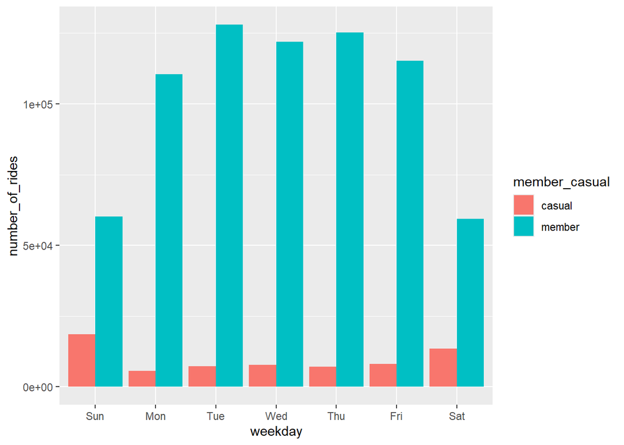

```r
ggplot(summarized_table, mapping = aes(weekday, number_of_rides, fill = member_casual)) + geom_col(position = "dodge")
```

Well the visualisation works but the y-axis can be more human readable, let’s change that.

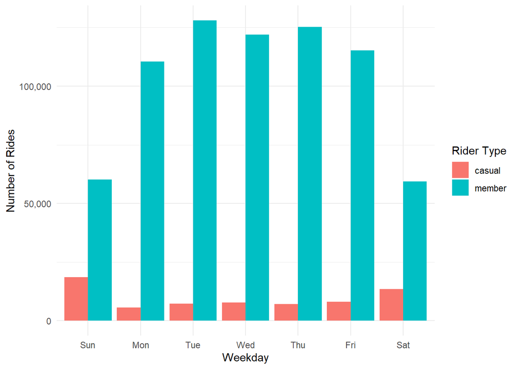

```r
ggplot(summarized_table, aes(x = weekday, y = number_of_rides, fill = member_casual)) +
  geom_col(position = "dodge") +
  scale_y_continuous(labels = comma) +
  labs(y = "Number of Rides", x = "Weekday", fill = "Rider Type") +
  theme_minimal()
```

Now let’s see visualisation for average duration by biker type

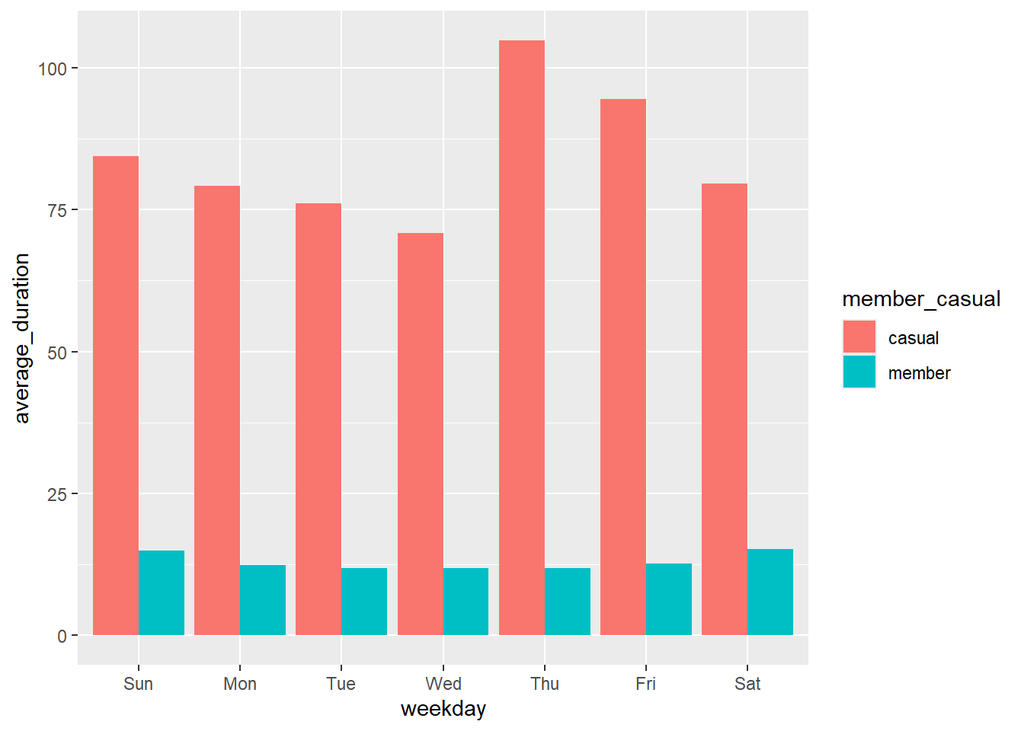

```r
ggplot(summarized_table, mapping = aes(x = weekday, y = average_duration, fill = member_casual)) + geom_col(position = "dodge")
```

## Conclusion

The analysis reveals clear differences in how casual riders and annual members use the Cyclistic bike-share system:

- **Ride Frequency**:  
  Annual members take significantly more rides during weekdays, suggesting that they use bikes for commuting or routine travel. In contrast, casual riders are more active on weekends, implying recreational use.
- **Ride Duration**:  
  Casual riders consistently have much longer average ride durations than members across all days of the week — especially on Thursdays and Fridays. This supports the idea that casual riders are exploring or riding for leisure rather than quick, practical trips.

### Key Takeaways for the Marketing Team:

- To convert casual users into members, consider targeting **weekend riders** with incentives like “Weekend Membership Trials” or “Leisure Plans”.
- Casual riders might be more likely to convert if offered value based on **longer duration needs**, such as day passes that transition into discounted membership options.
- Messaging should be tailored around **exploration, flexibility, and savings for longer rides**, which casual users clearly favor.

These insights will serve as the foundation for strategic recommendations in the next phase of the case study.

## Bonus Visualizations

Beyond the core weekday analysis, we explored additional trends to better understand user behavior. These visualizations provide further insights that could support more targeted marketing strategies.

### Ride count by hour of the day(faceted by user type)

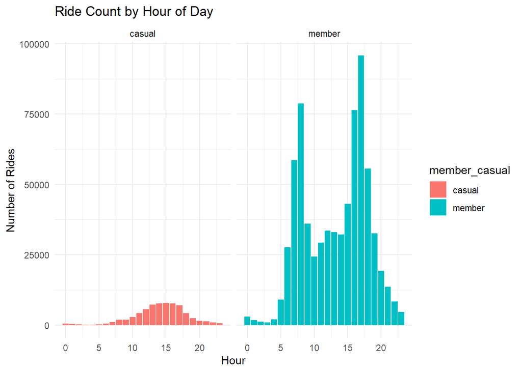

```r
all_trips %>%
  mutate(hour = hour(started_at)) %>%
  group_by(member_casual, hour) %>%
  summarise(rides = n(), .groups = "drop") %>%
  ggplot(aes(x = hour, y = rides, fill = member_casual)) +
  geom_col(position = "dodge") +
  facet_wrap(~member_casual) +
  labs(title = "Ride Count by Hour of Day", x = "Hour", y = "Number of Rides") +
  theme_minimal()
```

### Ride duration distribution by user type (box plot)

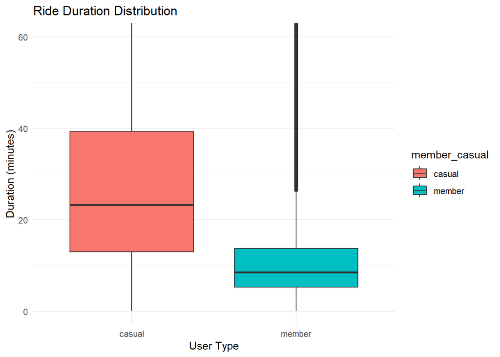

```r
ggplot(all_trips, aes(x = member_casual, y = ride_length, fill = member_casual)) +
  geom_boxplot() +
  coord_cartesian(ylim = c(0, 60)) +  # Focus on rides < 60 min
  labs(title = "Ride Duration Distribution", y = "Duration (minutes)", x = "User Type") +
  theme_minimal()
```

### Rides by age group

```r
df_2019$day_of_week <- factor(df_2019$day_of_week,
                                levels = c("Sunday", "Monday", "Tuesday", "Wednesday", "Thursday", "Friday", "Saturday"),
                                ordered = TRUE)
df_2019$weekday <- wday(df_2019$started_at, label = TRUE, abbr = TRUE)
```

```r
age_weekday_summary <- df_2019 %>% filter(age_group!="Unknown") %>%
  group_by(age_group, weekday) %>% summarise(rides=n(), .groups = "drop")
```

*Grouped Bar chart*

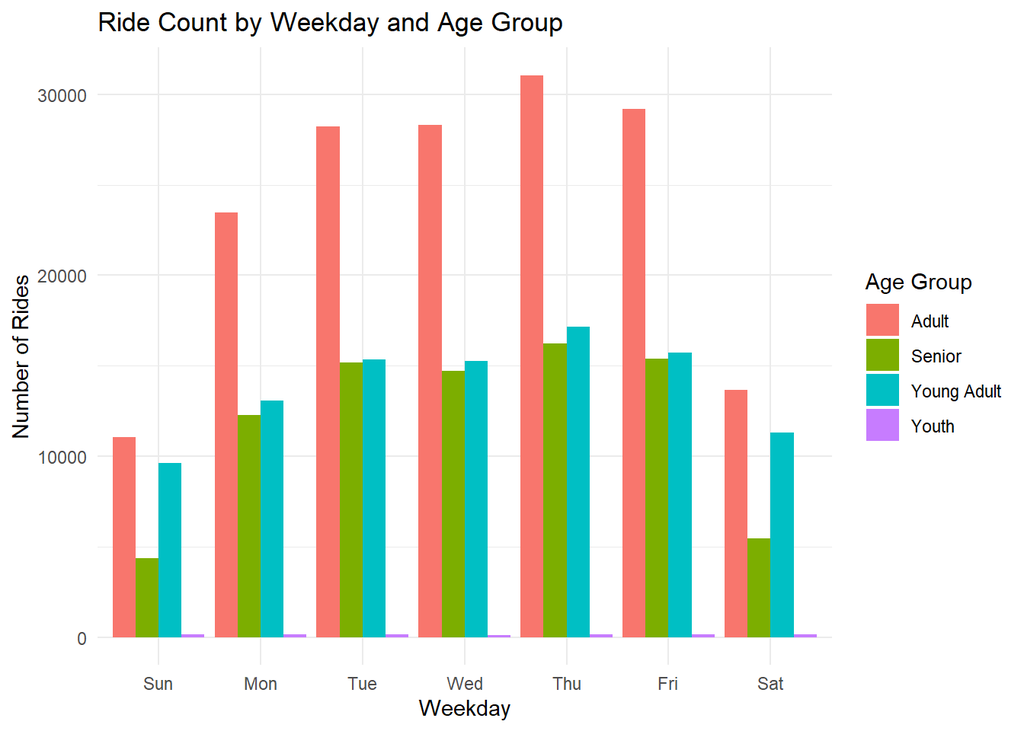

```r
ggplot(age_weekday_summary, aes(x = weekday, y = rides, fill = age_group)) +
  geom_col(position = "dodge") +
  labs(title = "Ride Count by Weekday and Age Group",
       x = "Weekday", y = "Number of Rides", fill = "Age Group") +
  theme_minimal()
```

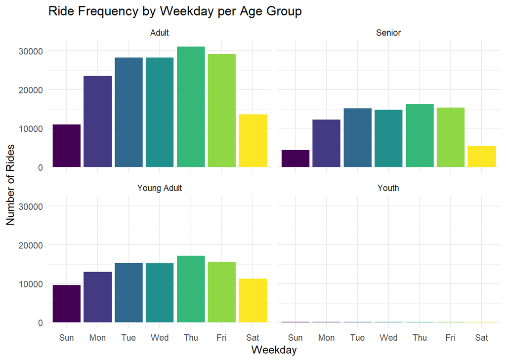

```r
ggplot(age_weekday_summary, aes(x = weekday, y = rides, fill = weekday)) +
  geom_col(show.legend = FALSE) +
  facet_wrap(~ age_group) +
  labs(title = "Ride Frequency by Weekday per Age Group",
       x = "Weekday", y = "Number of Rides") +
  theme_minimal()
```